# Bayesian Analysis of GHG Fluxes in Seasonal Wetlands

### 8c. Seasonal variation in fluxes (random effects on month)

> Updated to use M2c (CO₂ with organic carbon) and M3d (CH₄ linear + organic carbon), which represent our most complete understanding of the fixed effects. The month random intercepts capture residual seasonal variation not explained by SWC, organic carbon, or HAND.

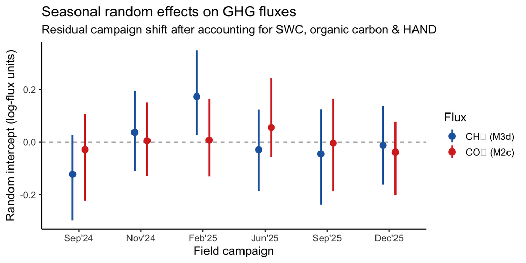

```r
# ── CO₂ month random effects from M2c ─────────────────────────────────────────
ranef_month_co2 <- ranef(mod_co2_C)$month %>%
  as.data.frame() %>%
  rownames_to_column("month") %>%
  rename(est = Estimate.Intercept, lo = Q2.5.Intercept, hi = Q97.5.Intercept) %>%
  mutate(month = factor(month, levels = c("set24","nov24","fev25","jun25","set25","dez25")),
         flux  = "CO₂ (M2c)")

# ── CH₄ month random effects from M3d (linear SWC + C) ───────────────────────
ranef_month_ch4 <- ranef(mod_ch4_C)$month %>%
  as.data.frame() %>%
  rownames_to_column("month") %>%
  rename(est = Estimate.Intercept, lo = Q2.5.Intercept, hi = Q97.5.Intercept) %>%
  mutate(month = factor(month, levels = c("set24","nov24","fev25","jun25","set25","dez25")),
         flux  = "CH₄ (M3d)")

bind_rows(ranef_month_co2, ranef_month_ch4) %>%
  mutate(month_label = recode(as.character(month),
    set24 = "Sep'24", nov24 = "Nov'24", fev25 = "Feb'25",
    jun25 = "Jun'25", set25 = "Sep'25", dez25 = "Dec'25"
  )) %>%
  ggplot(aes(x = month_label, y = est, ymin = lo, ymax = hi,
             colour = flux, group = flux)) +
  geom_hline(yintercept = 0, linetype = "dashed", colour = "grey50") +
  geom_linerange(position = position_dodge(0.4), linewidth = 1) +
  geom_point(position = position_dodge(0.4), size = 3) +
  scale_colour_manual(values = c("CO₂ (M2c)" = "#d73027", "CH₄ (M3d)" = "#2166ac")) +
  scale_x_discrete(limits = c("Sep'24","Nov'24","Feb'25","Jun'25","Sep'25","Dec'25")) +
  labs(title    = "Seasonal random effects on GHG fluxes",
       subtitle = "Residual campaign shift after accounting for SWC, organic carbon & HAND",
       x = "Field campaign", y = "Random intercept (log-flux units)",
       colour = "Flux") +
  theme_classic(base_size = 13)
```

```r
ggsave("Plots/Bayes_Synthesis_Seasonal.pdf", width = 8, height = 4)
```

### 8d. Campaign-level conditional effects (SWC, temperature, HAND)

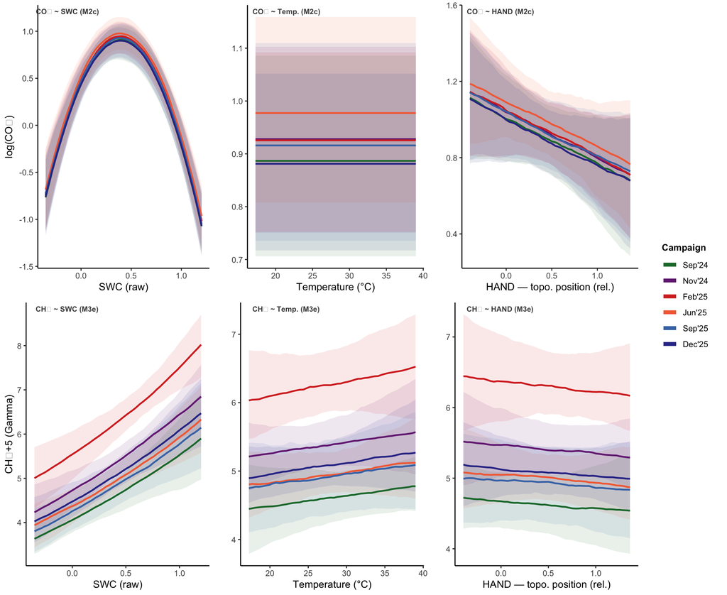

```r
# ── campaign display names and colours ────────────────────────────────────────
campaign_labels <- c(
  set24 = "Sep'24", nov24 = "Nov'24", fev25 = "Feb'25",
  jun25 = "Jun'25", set25 = "Sep'25", dez25 = "Dec'25"
)
campaign_colours <- c(
  "Sep'24" = "#1b7837",
  "Nov'24" = "#762a83",
  "Feb'25" = "#d73027",
  "Jun'25" = "#f46d43",
  "Sep'25" = "#4575b4",
  "Dec'25" = "#313695"
)

# ── helper: sweep one predictor, include month RE only ────────────────────────
pred_by_month <- function(model, focal_var, extra_cols = list(),
                          n_seq = 50, ndraws = 300) {
  seq_vals <- seq(-2.5, 2.5, length.out = n_seq)

  new_d <- expand_grid(
    val    = seq_vals,
    month  = factor(levels(df_an$month), levels = levels(df_an$month)),
    area   = unique(df_an$area)[1],
    point2 = unique(df_an$point2)[1]
  ) %>%
    mutate(swc_s  = if (focal_var == "swc_s")  val else 0,
           ts_s   = if (focal_var == "ts_s")   val else 0,
           hand_s = if (focal_var == "hand_s") val else 0)

  # add any extra constant columns needed by the model (e.g. C_s for M2c)
  for (nm in names(extra_cols)) new_d[[nm]] <- extra_cols[[nm]]

  new_d %>%
    add_epred_draws(model, ndraws = ndraws, re_formula = ~(1 | month)) %>%
    group_by(val, month) %>%
    summarise(med = median(.epred),
              lo  = quantile(.epred, 0.10),
              hi  = quantile(.epred, 0.90),
              .groups = "drop") %>%
    mutate(campaign = recode(as.character(month), !!!campaign_labels),
           campaign  = factor(campaign, levels = campaign_labels))
}

# ── CO₂: M2c (quadratic SWC + organic carbon) — C held at mean ───────────────
co2_swc  <- pred_by_month(mod_co2_C, "swc_s",  extra_cols = list(C_s = 0))
co2_ts   <- pred_by_month(mod_co2_C, "ts_s",   extra_cols = list(C_s = 0))
co2_hand <- pred_by_month(mod_co2_C, "hand_s", extra_cols = list(C_s = 0))

# ── CH₄: M3e Gamma (linear SWC, temperature, HAND) ───────────────────────────
ch4_swc  <- pred_by_month(mod_ch4_gamma, "swc_s")
ch4_ts   <- pred_by_month(mod_ch4_gamma, "ts_s")
ch4_hand <- pred_by_month(mod_ch4_gamma, "hand_s")

# ── axis back-transform values ─────────────────────────────────────────────────
ts_mean   <- mean(df_an$ts,     na.rm = TRUE)
ts_sd     <- sd(df_an$ts,       na.rm = TRUE)
hand_mean <- mean(df_an$hand_p, na.rm = TRUE)
hand_sd   <- sd(df_an$hand_p,   na.rm = TRUE)

# ── panel factory ─────────────────────────────────────────────────────────────
make_panel <- function(dat, x_label, y_label,
                       x_raw_mean = NULL, x_raw_sd = NULL) {
  if (!is.null(x_raw_mean))
    dat <- dat %>% mutate(val = val * x_raw_sd + x_raw_mean)

  ggplot(dat, aes(x = val, y = med,
                  colour = campaign, fill = campaign, group = campaign)) +
    geom_ribbon(aes(ymin = lo, ymax = hi), alpha = 0.10, colour = NA) +
    geom_line(linewidth = 0.9) +
    scale_colour_manual(values = campaign_colours) +
    scale_fill_manual(  values = campaign_colours) +
    labs(x = x_label, y = y_label, colour = "Campaign", fill = "Campaign") +
    theme_classic(base_size = 11) +
    theme(legend.position = "none", plot.title = element_blank())
}

# ── 6 panels ──────────────────────────────────────────────────────────────────
p_co2_swc  <- make_panel(co2_swc,  "SWC (raw)",                    "log(CO₂)",
                          swc_mean, swc_sd)
p_co2_ts   <- make_panel(co2_ts,   "Temperature (°C)",             "",
                          ts_mean,  ts_sd)
p_co2_hand <- make_panel(co2_hand, "HAND — topo. position (rel.)", "",
                          hand_mean, hand_sd)

p_ch4_swc  <- make_panel(ch4_swc,  "SWC (raw)",                    "CH₄+5 (Gamma)",
                          swc_mean, swc_sd)
p_ch4_ts   <- make_panel(ch4_ts,   "Temperature (°C)",             "",
                          ts_mean,  ts_sd)
p_ch4_hand <- make_panel(ch4_hand, "HAND — topo. position (rel.)", "",
                          hand_mean, hand_sd)

# ── shared legend ─────────────────────────────────────────────────────────────
legend_panel <- make_panel(co2_swc, "", "", swc_mean, swc_sd) +
  guides(colour = guide_legend(title = "Campaign",
                               override.aes = list(linewidth = 2, alpha = 1)),
         fill = "none") +
  theme(legend.position = "right",
        legend.title    = element_text(size = 10, face = "bold"),
        legend.text     = element_text(size = 9))

shared_legend <- cowplot::get_legend(legend_panel)

# ── assemble 2 × 3 grid + legend ──────────────────────────────────────────────
grid_plots <- cowplot::plot_grid(
  p_co2_swc,  p_co2_ts,  p_co2_hand,
  p_ch4_swc,  p_ch4_ts,  p_ch4_hand,
  nrow   = 2,
  labels = c("CO₂ ~ SWC (M2c)", "CO₂ ~ Temp. (M2c)", "CO₂ ~ HAND (M2c)",
             "CH₄ ~ SWC (M3e)", "CH₄ ~ Temp. (M3e)", "CH₄ ~ HAND (M3e)"),
  label_size = 8, label_colour = "grey30", label_x = 0.02, label_y = 0.98
)

cowplot::plot_grid(grid_plots, shared_legend, rel_widths = c(1, 0.13))
```

```r
ggsave("Plots/Bayes_Temporal_ConditionalEffects.pdf", width = 12, height = 8)
```

> **How to read this plot:** Each coloured line is one field campaign. The **vertical spread between lines** is the estimated month random-intercept — the baseline flux level that cannot be explained by SWC, temperature or HAND alone (e.g. antecedent rainfall, phenological effects, litter inputs). The **slope and curvature** is shared across campaigns because the model assumes fixed relationship shapes; a natural next step would be adding random slopes for SWC to test whether the moisture sensitivity itself changes across seasons.

## 9. Model Diagnostics

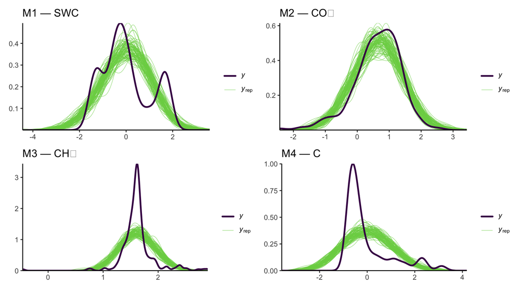

```r
# Posterior predictive checks for each model
p_ppc1 <- pp_check(mod_swc, ndraws = 100) + ggtitle("M1 — SWC") + theme_classic()
p_ppc2 <- pp_check(mod_co2, ndraws = 100) + ggtitle("M2 — CO₂") + theme_classic()
p_ppc3 <- pp_check(mod_ch4, ndraws = 100) + ggtitle("M3 — CH₄") + theme_classic()
p_ppc4 <- pp_check(mod_C,   ndraws = 100) + ggtitle("M4 — C") + theme_classic()

(p_ppc1 + p_ppc2) / (p_ppc3 + p_ppc4)
```

```r
ggsave("Plots/Bayes_PPChecks.pdf", width = 10, height = 7)
```

```r
# Bayesian R²
cat("=== Bayesian R² ===\n")
```

```
## === Bayesian R² ===
```

```r
cat("M1 SWC:  "); print(bayes_R2(mod_swc))
```

```
## M1 SWC:
```

```
##     Estimate  Est.Error      Q2.5     Q97.5
## R2 0.5033833 0.03337875 0.4310561 0.5621073
```

```r
cat("M2 CO2:  "); print(bayes_R2(mod_co2))
```

```
## M2 CO2:
```

```
##     Estimate Est.Error     Q2.5     Q97.5
## R2 0.4442397 0.0488899 0.337687 0.5287978
```

```r
cat("M3 CH4:  "); print(bayes_R2(mod_ch4))
```

```
## M3 CH4:
```

```
##     Estimate  Est.Error      Q2.5     Q97.5
## R2 0.3489435 0.04676442 0.2546129 0.4362506
```

```r
cat("M4 C:    "); print(bayes_R2(mod_C))
```

```
## M4 C:
```

```
##     Estimate  Est.Error      Q2.5     Q97.5
## R2 0.5029533 0.03385749 0.4293143 0.5624755
```

*Models cached as `.rds` in `Data/`. Re-knit after deleting those files to refit.*